# Detección GBM - analisis de los factores de riesgo

# Análisis de la esperanza de vida

La esperanza de vida se corresponde con los dias que transcurren desde la primera daignósis hasta la muerte.

```r
dataset_life_expect <- dataset_risk

dataset_life_expect <- dataset_life_expect[, -c(cause_of_death_index, vital_status_index)]
class_val_index <- which(names(dataset_life_expect) == 'life_expectancy', arr.ind = TRUE)
numeric_var_indexes_life_expect <- c(which(sapply(dataset_life_expect, class) == 'numeric', arr.ind = TRUE), which(sapply(dataset_life_expect, class) == 'integer', arr.ind = TRUE))
numeric_var_indexes_life_expect <- numeric_var_indexes_life_expect[-which(numeric_var_indexes_life_expect ==  class_val_index, arr.ind = TRUE)]
non_numeric_var_life_expect <- which(sapply(dataset_life_expect, class) == 'factor', arr.ind = TRUE)

dataset_life_expect <- droplevels(dataset_life_expect)
summary(dataset_life_expect)
```

```
      age                                                                                                      alcohol_consumption      bmi             case_id       gender
 Min.   :24.00   Alcohol consumption equal to or less than 2 drinks per day for men and 1 drink or less per day for women:29       Min.   : 1.84   C3L-00016:  1   Female:60
 1st Qu.:50.00   Alcohol consumption more than 2 drinks per day for men and more than 1 drink per day for women          : 9       1st Qu.:22.61   C3L-00019:  1   Male  :98
 Median :60.00   Consumed alcohol in the past, but currently a non-drinker                                               : 5       Median :25.14   C3L-00265:  1
 Mean   :58.48   Lifelong non-drinker                                                                                    :90       Mean   :25.71   C3L-00278:  1
 3rd Qu.:68.00   NA's                                                                                                    :25       3rd Qu.:28.06   C3L-00349:  1
 Max.   :88.00                                                                                                                     Max.   :46.97   C3L-00424:  1
                                                                                                                                                   (Other)  :152
  height_in_cm   number_of_pack_years_smoked                                                     tobacco_smoking_history                           tumor_site tumor_size_in_cm
 Min.   :150.0   Min.   : 0.000              Current reformed smoker within past 15 years                    : 3         Temporal Lobe                  :46   Min.   :1.000
 1st Qu.:165.0   1st Qu.: 0.000              Current reformed smoker, more than 15 years                     :13         Frontal Lobe                   :40   1st Qu.:3.500
 Median :172.0   Median : 0.000              Current reformed smoker, years unknown                          : 1         Parietal Lobe                  :21   Median :4.600
 Mean   :171.5   Mean   : 6.441              Current smoker: Includes daily and non-daily smokers            :25         Occipital Lobe                 :10   Mean   :4.519
 3rd Qu.:178.0   3rd Qu.: 0.000              Lifelong non-smoker: Less than 100 cigarettes smoked in lifetime:99         Temporal Lobe and Parietal Lobe: 4   3rd Qu.:5.500
 Max.   :198.0   Max.   :66.000              NA's                                                            :17         (Other)                        :16   Max.   :8.500
 NA's   :1       NA's   :30                                                                                              NA's                           :21   NA's   :1
  weight_in_kg    years_high_alcohol_quantity_consumed time_monitored   life_expectancy
 Min.   : 29.00   Min.   : 0.000                       Min.   :   0.0   Min.   :   1.0
 1st Qu.: 66.00   1st Qu.: 0.000                       1st Qu.: 205.2   1st Qu.: 194.5
 Median : 75.00   Median : 0.000                       Median : 386.0   Median : 379.5
 Mean   : 76.42   Mean   : 1.365                       Mean   : 445.5   Mean   : 405.2
 3rd Qu.: 87.00   3rd Qu.: 0.000                       3rd Qu.: 715.0   3rd Qu.: 579.0
 Max.   :166.00   Max.   :50.000                       Max.   :1115.0   Max.   :1115.0
                  NA's   :32                                            NA's   :64
```

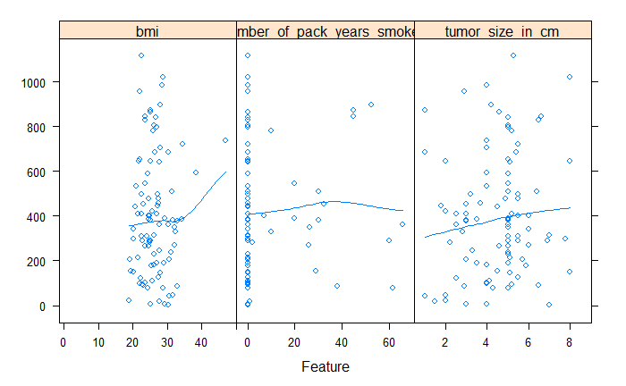

```r
# Scatter plots for numeric variables
featurePlot(x = dataset_life_expect[, numeric_var_indexes_life_expect[1:3]],
            y = dataset_life_expect$life_expectancy,
            plot = "scatter",
            type = c("p", "smooth"),
            span = 1,
            layout= c(3, 1))
```

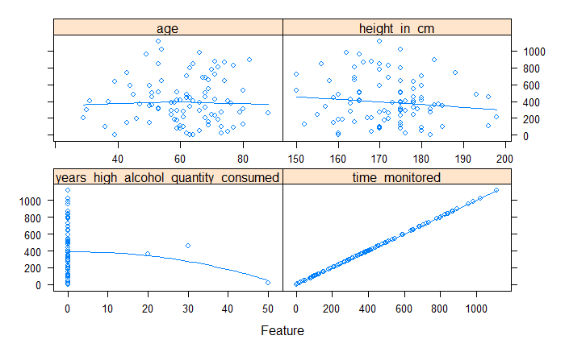

```r
featurePlot(x = dataset_life_expect[, numeric_var_indexes_life_expect[4:7]],
            y = dataset_life_expect$life_expectancy,
            plot = "scatter",
            type = c("p", "smooth"),
            span = 1,
            layout= c(2, 2))
```

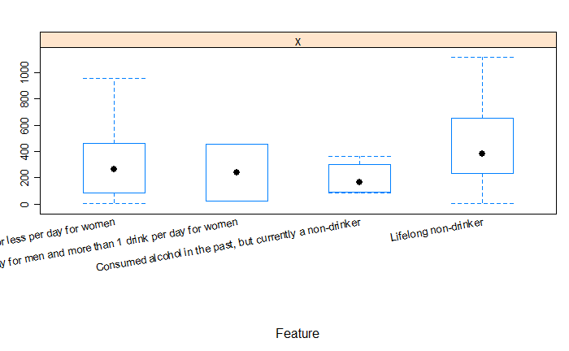

```r
# Boxplots
featurePlot(y=dataset_life_expect[, non_numeric_var_life_expect[1]],
            x=dataset_life_expect$life_expectancy, plot="box",
            scales = list(y = list(relation="free"),
                          x = list(rot = 10)))
```

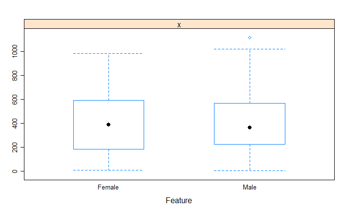

```r
featurePlot(y=dataset_life_expect[, non_numeric_var_life_expect[3]],
            x=dataset_life_expect$life_expectancy, plot="box",
            scales = list(y = list(relation="free"),
                          x = list(rot = 0)))
```

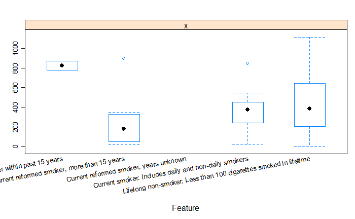

```r
featurePlot(y=dataset_life_expect[, non_numeric_var_life_expect[4]],
            x=dataset_life_expect$life_expectancy, plot="box",
            scales = list(y = list(relation="free"),
                          x = list(rot = 10)))
```

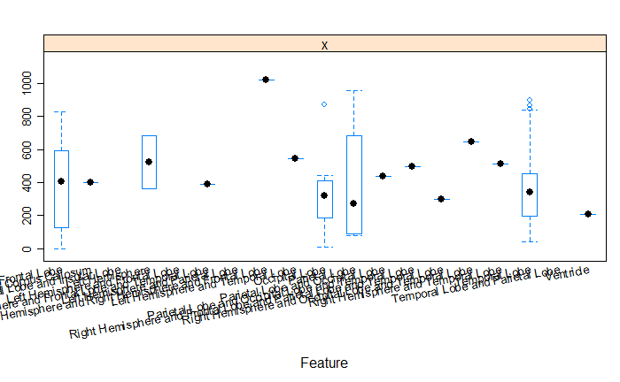

```r
featurePlot(y=dataset_life_expect[, non_numeric_var_life_expect[5]],
            x=dataset_life_expect$life_expectancy, plot="box",
            scales = list(y = list(relation="free"),
                          x = list(rot = 10)))
```

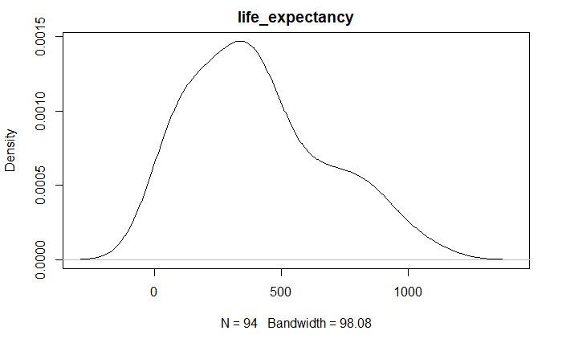

```r
# Class variable
plot(density(dataset_life_expect$life_expectancy[which(!is.na(dataset_life_expect$life_expectancy))]), main=names(dataset_life_expect)[class_val_index])
```

## IMPUTACIÓN DE LAS VARIABLES

Con el objetivo de poder analizar el impacto que todas las variables tienen en la supervivencia del paciente y calcular las regresiones de Cox y RandomForest, se procede a la imputación de los valores definidos como NA en el dataset. Para la imputación de las variables se emplea el método Predictive Mean Matching (PMM).

```r
# Cantidad de valores NA que hay que imputar
sum(is.na(dataset_risk))
```

```
[1] 191
```

```r
na_loc <- which(is.na(dataset_risk), arr.ind=TRUE)
na_loc_colums <- unique(na_loc[,2])
na_loc_colums <- na_loc_colums[-which(na_loc_colums == life_expectancy_index, arr.ind=TRUE)]

# Variables con valores NA presentes
names(dataset_risk)[na_loc_colums]
```

```
[1] "alcohol_consumption"                  "height_in_cm"                         "number_of_pack_years_smoked"          "tobacco_smoking_history"
[5] "tumor_site"                           "tumor_size_in_cm"                     "years_high_alcohol_quantity_consumed"
```

```r
dataset_risk_completed <- dataset_risk[, -life_expectancy_index]

imp_pmm <- mice(dataset_risk_completed, m = 3, method= "pmm", printFlag = FALSE, seed = 7)
```

```
Number of logged events: 231
```

```r
dataset_risk_completed <- complete(imp_pmm)

for(row in 1:dim(dataset_risk_completed)[1]){
  if(dataset_risk_completed[row, ]$tobacco_smoking_history == "Lifelong non-smoker: Less than 100 cigarettes smoked in lifetime" && dataset_risk_completed[row, ]$number_of_pack_years_smoked != 0) {
    dataset_risk_completed[row, ]$number_of_pack_years_smoked <- 0
  } else if(dataset_risk_completed[row, ]$tobacco_smoking_history != "Lifelong non-smoker: Less than 100 cigarettes smoked in lifetime" && dataset_risk_completed[row, ]$number_of_pack_years_smoked == 0){
    dataset_risk_completed[row, ]$number_of_pack_years_smoked <- NA
  }
  if(dataset_risk_completed[row, ]$alcohol_consumption == "Alcohol consumption more than 2 drinks per day for men and more than 1 drink per day for women" && dataset_risk_completed[row, ]$years_high_alcohol_quantity_consumed == 0) {
    dataset_risk_completed[row, ]$years_high_alcohol_quantity_consumed <- NA
  } else if(dataset_risk_completed[row, ]$alcohol_consumption == "Lifelong non-drinker" && dataset_risk_completed[row, ]$years_high_alcohol_quantity_consumed != 0){
    dataset_risk_completed[row, ]$years_high_alcohol_quantity_consumed <- 0
  }
}

imp_pmm <- mice(dataset_risk_completed, m = 1, method= "pmm", printFlag = FALSE, seed = 3)
```

```
Number of logged events: 22
```

```r
dataset_risk_completed <- complete(imp_pmm)

# Cantidad de valores NA después de imputar
print(sum(is.na(dataset_risk_completed)))
```

```
[1] 0
```

```r
dataset_risk_completed$life_expectancy <- dataset_risk$life_expectancy
```

## REGRESIÓN DE COX

El primer método empleado para determinar las probabilidades de supervivencia del paciente es la regresión de Cox. Una vez contamos con el dataset con los valores imputados, procedemos a calcular la regresión de Cox con todas las variables disponibles.

```r
dataset_survival <- dataset_risk_completed
dataset_survival$vital_status <- as.numeric(dataset_survival$vital_status)
dataset_survival$vital_status[which(dataset_survival$vital_status == 2)] <- 0

cox.model.all_vars <- coxph(Surv(time_monitored, vital_status) ~ age + gender + bmi + alcohol_consumption + years_high_alcohol_quantity_consumed + tobacco_smoking_history + number_of_pack_years_smoked + weight_in_kg + height_in_cm + tumor_site + tumor_size_in_cm, data = dataset_survival)
```

```
Loglik converged before variable  16,18,31 ; coefficient may be infinite.
```

```r
summary(cox.model.all_vars, digits = 3)
```

```
Call:
coxph(formula = Surv(time_monitored, vital_status) ~ age + gender +
    bmi + alcohol_consumption + years_high_alcohol_quantity_consumed +
    tobacco_smoking_history + number_of_pack_years_smoked + weight_in_kg +
    height_in_cm + tumor_site + tumor_size_in_cm, data = dataset_survival)

  n= 158, number of events= 94

                                                                                                                        coef  exp(coef)   se(coef)      z Pr(>|z|)
age                                                                                                                3.432e-02  1.035e+00  1.159e-02  2.962  0.00305 **
genderMale                                                                                                        -5.433e-01  5.808e-01  3.927e-01 -1.384  0.16648
bmi                                                                                                                2.131e-01  1.238e+00  1.697e-01  1.256  0.20923
alcohol_consumptionAlcohol consumption more than 2 drinks per day for men and more than 1 drink per day for women -1.645e+00  1.929e-01  1.562e+00 -1.053  0.29225
alcohol_consumptionConsumed alcohol in the past, but currently a non-drinker                                       1.339e-01  1.143e+00  1.436e+00  0.093  0.92572
alcohol_consumptionLifelong non-drinker                                                                           -8.932e-01  4.093e-01  3.149e-01 -2.836  0.00457 **
years_high_alcohol_quantity_consumed                                                                               4.683e-02  1.048e+00  4.255e-02  1.101  0.27111
tobacco_smoking_historyCurrent reformed smoker, more than 15 years                                                 9.534e-01  2.595e+00  8.901e-01  1.071  0.28412
tobacco_smoking_historyCurrent reformed smoker, years unknown                                                      8.355e-01  2.306e+00  1.264e+00  0.661  0.50869
tobacco_smoking_historyCurrent smoker: Includes daily and non-daily smokers                                        1.329e+00  3.776e+00  8.869e-01  1.498  0.13408
tobacco_smoking_historyLifelong non-smoker: Less than 100 cigarettes smoked in lifetime                            7.360e-01  2.088e+00  8.851e-01  0.832  0.40567
number_of_pack_years_smoked                                                                                       -1.687e-03  9.983e-01  9.117e-03 -0.185  0.85319
weight_in_kg                                                                                                      -5.079e-02  9.505e-01  5.539e-02 -0.917  0.35918
height_in_cm                                                                                                       8.026e-02  1.084e+00  5.744e-02  1.397  0.16237
tumor_siteFrontal lobe and Corpus Callosum                                                                         1.413e+00  4.107e+00  1.178e+00  1.199  0.23059
tumor_siteFrontal Lobe and Temporal Lobe and Insular Lobe                                                         -1.961e+01  3.031e-09  1.039e+04 -0.002  0.99849
tumor_siteLeft Hemisphere                                                                                         -7.585e-01  4.684e-01  1.005e+00 -0.755  0.45021
tumor_siteLeft Hemisphere and Frontal Lobe                                                                        -1.792e+01  1.644e-08  4.980e+03 -0.004  0.99713
tumor_siteLeft Hemisphere and Frontal Lobe and Temporal Lobe                                                       1.136e+00  3.113e+00  1.134e+00  1.001  0.31675
tumor_siteLeft Hemisphere and Parietal Lobe                                                                        1.228e-01  1.131e+00  1.080e+00  0.114  0.90952
tumor_siteLeft Hemisphere and Right Hemisphere and Frontal Lobe                                                   -5.192e-01  5.950e-01  7.542e-01 -0.688  0.49118
tumor_siteLeft Hemisphere and Temporal Lobe                                                                       -1.306e+00  2.709e-01  1.081e+00 -1.209  0.22684
tumor_siteOccipital Lobe                                                                                           2.062e-01  1.229e+00  4.505e-01  0.458  0.64709
tumor_siteParietal Lobe                                                                                           -1.113e-01  8.947e-01  3.549e-01 -0.314  0.75382
tumor_siteParietal Lobe and Occipital Lobe                                                                         1.331e+00  3.786e+00  1.063e+00  1.253  0.21027
tumor_siteParietal Lobe and Occipital Lobe and Temporal Lobe                                                       9.827e-01  2.672e+00  8.075e-01  1.217  0.22363
tumor_siteRight Hemisphere and Frontal Lobe and Parietal Lobe and Temporal Lobe                                    1.976e+00  7.215e+00  1.167e+00  1.694  0.09032 .
tumor_siteRight Hemisphere and Occipital Lobe and Temporal Lobe                                                    5.596e-01  1.750e+00  1.091e+00  0.513  0.60794
tumor_siteRight Hemisphere and Temporal Lobe                                                                       2.348e-01  1.265e+00  1.116e+00  0.210  0.83339
tumor_siteTemporal Lobe                                                                                           -1.931e-01  8.244e-01  3.245e-01 -0.595  0.55172
tumor_siteTemporal Lobe and Parietal Lobe                                                                         -1.809e+01  1.387e-08  5.845e+03 -0.003  0.99753
```

[output cut: 29 more lines]

```
tumor_siteParietal Lobe                                                                                           8.947e-01  1.118e+00  0.446201    1.7939
tumor_siteParietal Lobe and Occipital Lobe                                                                        3.786e+00  2.641e-01  0.471670   30.3949
tumor_siteParietal Lobe and Occipital Lobe and Temporal Lobe                                                      2.672e+00  3.743e-01  0.548804   13.0060
tumor_siteRight Hemisphere and Frontal Lobe and Parietal Lobe and Temporal Lobe                                   7.215e+00  1.386e-01  0.732984   71.0110
tumor_siteRight Hemisphere and Occipital Lobe and Temporal Lobe                                                   1.750e+00  5.714e-01  0.206315   14.8437
tumor_siteRight Hemisphere and Temporal Lobe                                                                      1.265e+00  7.907e-01  0.141878   11.2723
tumor_siteTemporal Lobe                                                                                           8.244e-01  1.213e+00  0.436418    1.5572
tumor_siteTemporal Lobe and Parietal Lobe                                                                         1.387e-08  7.211e+07  0.000000       Inf
tumor_siteVentricle                                                                                               2.567e+01  3.895e-02  2.752156  239.4831
tumor_size_in_cm                                                                                                  1.171e+00  8.541e-01  0.982772    1.3950

Concordance= 0.701  (se = 0.03 )
Likelihood ratio test= 60.28  on 33 df,   p=0.003
Wald test            = 36.5  on 33 df,   p=0.3
Score (logrank) test = 60.78  on 33 df,   p=0.002
```

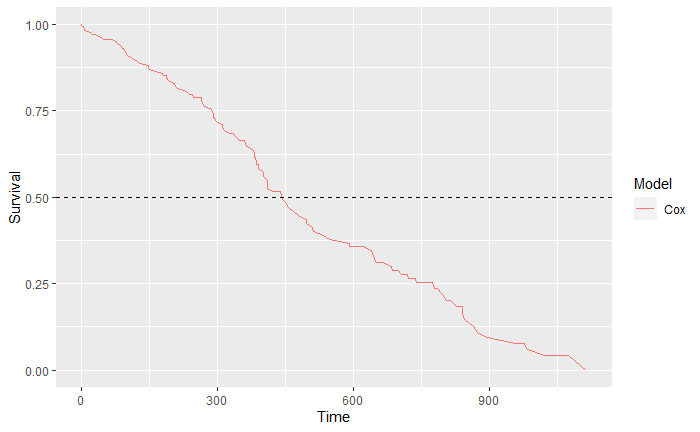

```r
cox.model.all_vars.fit <- survfit(cox.model.all_vars)

df <- data.frame(cox.model.all_vars.fit$time, cox.model.all_vars.fit$surv, "Cox")
names(df) <- c("Time", "Survival", "Model")

ggplot(df, aes(x = Time, y = Survival, color = Model)) + geom_line() + ylim(0, 1) + geom_hline(yintercept = 0.5, linetype="dashed", color = "black")
```

```r
anova(cox.model.all_vars)
```

```
Loglik converged before variable  16,18,31 ; coefficient may be infinite.
```

```
Analysis of Deviance Table
 Cox model: response is Surv(time_monitored, vital_status)
Terms added sequentially (first to last)

                                      loglik   Chisq Df Pr(>|Chi|)
NULL                                 -397.19
age                                  -392.94  8.4953  1   0.003561 **
gender                               -392.78  0.3277  1   0.567011
bmi                                  -390.75  4.0454  1   0.044291 *
alcohol_consumption                  -384.57 12.3632  3   0.006237 **
years_high_alcohol_quantity_consumed -383.85  1.4469  1   0.229018
tobacco_smoking_history              -382.17  3.3655  4   0.498626
number_of_pack_years_smoked          -382.10  0.1219  1   0.726960
weight_in_kg                         -381.32  1.5700  1   0.210208
height_in_cm                         -380.58  1.4828  1   0.223337
tumor_site                           -368.63 23.9056 18   0.158145
tumor_size_in_cm                     -367.05  3.1510  1   0.075881 .
---
Signif. codes:  0 ‘***’ 0.001 ‘**’ 0.01 ‘*’ 0.05 ‘.’ 0.1 ‘ ’ 1
```

Mediante los tests ANOVA se ha determinado la relevancia de las variables en el modelo de Cox. La mayoría de ellos no parecen ser relevantes (p < 0.05), estando por debajo de ese valor únicamente las variables de edad, BMI y historial de consumo de alcohol (age, bmi y alcohol_consumption). Para asegurarnos de que esto se cumple, creamos un segundo modelo de Cox solo con las variables determinadas como relevantes y comparamos los resultados de los dos modelos mediante los tests ANOVA.

```r
cox.model.select_vars <- coxph(Surv(time_monitored, vital_status) ~ age + bmi + alcohol_consumption, data = dataset_survival)
# summary(cox.model.select_vars, digits = 3)
cox.model.select_vars.fit <- survfit(cox.model.select_vars)
summary(cox.model.select_vars, digits = 3)
```

```
Call:
coxph(formula = Surv(time_monitored, vital_status) ~ age + bmi +
    alcohol_consumption, data = dataset_survival)

  n= 158, number of events= 94

                                                                                                                      coef exp(coef) se(coef)      z Pr(>|z|)
age                                                                                                                0.02557   1.02590  0.00830  3.080  0.00207 **
bmi                                                                                                                0.03495   1.03557  0.02145  1.629  0.10327
alcohol_consumptionAlcohol consumption more than 2 drinks per day for men and more than 1 drink per day for women -0.99759   0.36877  0.75170 -1.327  0.18447
alcohol_consumptionConsumed alcohol in the past, but currently a non-drinker                                       1.13883   3.12312  0.57054  1.996  0.04593 *
alcohol_consumptionLifelong non-drinker                                                                           -0.65549   0.51919  0.26409 -2.482  0.01306 *
---
Signif. codes:  0 ‘***’ 0.001 ‘**’ 0.01 ‘*’ 0.05 ‘.’ 0.1 ‘ ’ 1

                                                                                                                  exp(coef) exp(-coef) lower .95 upper .95
age                                                                                                                  1.0259     0.9748   1.00934    1.0427
bmi                                                                                                                  1.0356     0.9657   0.99293    1.0800
alcohol_consumptionAlcohol consumption more than 2 drinks per day for men and more than 1 drink per day for women    0.3688     2.7117   0.08451    1.6092
alcohol_consumptionConsumed alcohol in the past, but currently a non-drinker                                         3.1231     0.3202   1.02081    9.5550
alcohol_consumptionLifelong non-drinker                                                                              0.5192     1.9261   0.30941    0.8712

Concordance= 0.635  (se = 0.033 )
Likelihood ratio test= 25.22  on 5 df,   p=1e-04
Wald test            = 28.03  on 5 df,   p=4e-05
Score (logrank) test = 31.59  on 5 df,   p=7e-06
```

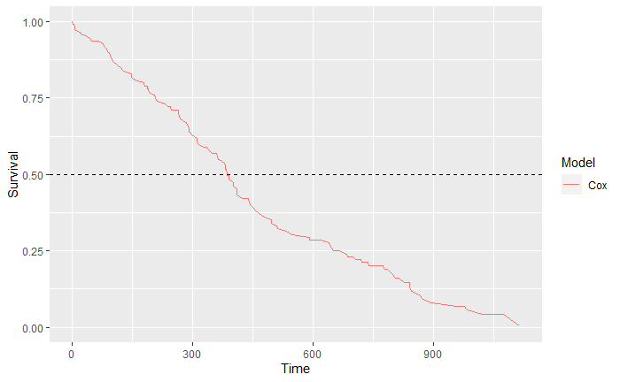

```r
df <- data.frame(cox.model.select_vars.fit$time, cox.model.select_vars.fit$surv, "Cox")
names(df) <- c("Time", "Survival", "Model")

ggplot(df, aes(x = Time, y = Survival, color = Model)) + geom_line() + ylim(0, 1) + geom_hline(yintercept = 0.5, linetype="dashed", color = "black")
```

```r
anova(cox.model.select_vars)
```

```
Analysis of Deviance Table
 Cox model: response is Surv(time_monitored, vital_status)
Terms added sequentially (first to last)

                     loglik   Chisq Df Pr(>|Chi|)
NULL                -397.19
age                 -392.94  8.4953  1   0.003561 **
bmi                 -390.76  4.3687  1   0.036605 *
alcohol_consumption -384.58 12.3596  3   0.006247 **
---
Signif. codes:  0 ‘***’ 0.001 ‘**’ 0.01 ‘*’ 0.05 ‘.’ 0.1 ‘ ’ 1
```

```r
anova(cox.model.select_vars, cox.model.all_vars, test = "LRT")
```

```
Analysis of Deviance Table
 Cox model: response is  Surv(time_monitored, vital_status)
 Model 1: ~ age + bmi + alcohol_consumption
 Model 2: ~ age + gender + bmi + alcohol_consumption + years_high_alcohol_quantity_consumed + tobacco_smoking_history + number_of_pack_years_smoked + weight_in_kg + height_in_cm + tumor_site + tumor_size_in_cm
   loglik  Chisq Df P(>|Chi|)
1 -384.58
2 -367.05 35.052 28    0.1684
```

El test ANOVA muestra un valor p > 0.05 por lo que podemos concluir que la diferencia entre ambos modelos no es relevante, confirmando que las variables seleccionadas son suficiente para calcular el modelo de supervivencia y que son las más determinantes a la hora de predecir las probabilidades de supervivencia del paciente que padece de GBM.

## RANDOM FOREST

Para comparar el modelo de supervivencia obtenido mediante la regresión de Cox con otro modelo se implementa otro modelo basádo en el algoritmo Random Forest. Se calcula el modelo de supervivencia de todas las variables y obtenemos las importancias asignadas a cada una de las variables por el modelo mediante el método de permutación. Esta métrica nos permite determinan como aumenta el error en la predicción al eliminar la variable.

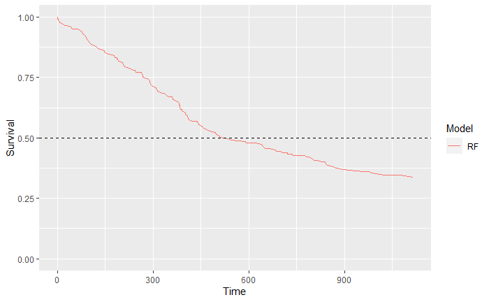

```r
# calcular el p-value
names(dataset_survival) <- janitor::make_clean_names(names(dataset_survival), use_make_names = TRUE)

r_fit.all_vars <- ranger(Surv(time = time_monitored, event = vital_status) ~  age + gender + bmi + alcohol_consumption + years_high_alcohol_quantity_consumed + tobacco_smoking_history + number_of_pack_years_smoked + tumor_site + tumor_size_in_cm + height_in_cm + weight_in_kg, data = dataset_survival,
                         num.trees = 525,
                         importance = "permutation",
                         splitrule = "extratrees",
                         num.random.splits = 20,
                         scale.permutation.importance = TRUE,
                         verbose = TRUE, seed = 10)

surv_prob <- data.frame(r_fit.all_vars$survival)
avg_prob_allvars <- sapply(surv_prob, mean)

df <- data.frame(r_fit.all_vars$unique.death.times, avg_prob_allvars, rep("RF", length(r_fit.all_vars$unique.death.times)))
names(df) <- c("Time", "Survival", "Model")

ggplot(df, aes(x = Time, y = Survival, color = Model)) + geom_line() + ylim(0, 1) + geom_hline(yintercept = 0.5, linetype="dashed", color = "black")
```

```r
# Plot importancias
var_imp <- data.frame(sort(round(r_fit.all_vars$variable.importance, 4), decreasing = TRUE))
names(var_imp) <- "importance"
var_imp
```

|  | importance |
| --- | --- |
| alcohol_consumption | 4.8911 |
| age | 4.0307 |
| tobacco_smoking_history | 1.6291 |
| height_in_cm | 0.7384 |
| gender | 0.5861 |
| weight_in_kg | 0.3770 |
| tumor_size_in_cm | 0.3219 |
| years_high_alcohol_quantity_consumed | -1.3338 |
| bmi | -1.7548 |
| number_of_pack_years_smoked | -3.4414 |

[output cut: 1 more lines]

```r
# # Calcular el p-value para ver si las variables son representativas o no para el modelo
# importance_pvalues(r_fit.all_vars, method = "altmann", data = dataset_survival, formula = Surv(time = time_monitored, event = vital_status) ~  age + gender + bmi + alcohol_consumption + years_high_alcohol_quantity_consumed + tobacco_smoking_history + number_of_pack_years_smoked + tumor_site + tumor_size_in_cm)
```

```r
# Variables a tener en cuenta en el siguiente modelo
var_imp <- sort(r_fit.all_vars$variable.importance, decreasing = TRUE)
which(var_imp > 0, arr.ind = TRUE)
```

```
    alcohol_consumption                     age tobacco_smoking_history            height_in_cm                  gender            weight_in_kg        tumor_size_in_cm
                      1                       2                       3                       4                       5                       6                       7
```

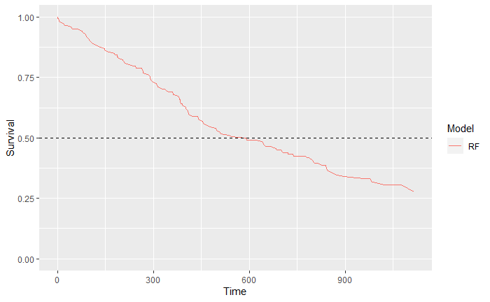

```r
r_fit.selec_vars <- ranger(Surv(time = time_monitored, event = vital_status) ~  age + tobacco_smoking_history + alcohol_consumption, data = dataset_survival,
                           num.trees = 525,
                           importance = "permutation",
                           splitrule = "extratrees",
                           num.random.splits = 20,
                           scale.permutation.importance = TRUE,
                           verbose = TRUE, seed = 10)

surv_prob <- data.frame(r_fit.selec_vars$survival)
avg_prob_selecvars <- sapply(surv_prob, mean)

df <- data.frame(r_fit.selec_vars$unique.death.times, avg_prob_selecvars, rep("RF", length(r_fit.selec_vars$unique.death.times)))
names(df) <- c("Time", "Survival", "Model")

ggplot(df, aes(x = Time, y = Survival, color = Model)) + geom_line() + ylim(0, 1) + geom_hline(yintercept = 0.5, linetype="dashed", color = "black")
```

```r
# Plot importancias
var_imp <- data.frame(sort(round(r_fit.selec_vars$variable.importance, 4), decreasing = TRUE))
names(var_imp) <- "importance"
var_imp
```

|  | importance |
| --- | --- |
| alcohol_consumption | 15.7071 |
| age | 8.5162 |
| tobacco_smoking_history | 3.7906 |